# Code_Handout

Jackie Vogel, Sarah Millard, Ignacio Luque, Leo Walker

## Multinomial Logistic Regression

dataset is from: https://www.kaggle.com/datasets/shivamb/machine-predictive-maintenance-classification

It is a synthetic dataset that reflects what is encountered in industry.

```r
pred_maint <-read.csv("../data/predictive_maintenance.csv", header=TRUE, sep= ",")
str(pred_maint)
```

```
## 'data.frame':    10000 obs. of  10 variables:
##  $ UDI                  : int  1 2 3 4 5 6 7 8 9 10 ...
##  $ Product_ID           : chr  "M14860" "L47181" "L47182" "L47183" ...
##  $ Type                 : chr  "M" "L" "L" "L" ...
##  $ Air_temperature_K    : num  298 298 298 298 298 ...
##  $ Process_temperature_K: num  309 309 308 309 309 ...
##  $ Rotational_speed_rpm : int  1551 1408 1498 1433 1408 1425 1558 1527 1667 1741 ...
##  $ Torque_Nm            : num  42.8 46.3 49.4 39.5 40 41.9 42.4 40.2 28.6 28 ...
##  $ Tool.wear_min        : int  0 3 5 7 9 11 14 16 18 21 ...
##  $ Target               : int  0 0 0 0 0 0 0 0 0 0 ...
##  $ Failure_Type         : chr  "No Failure" "No Failure" "No Failure" "No Failure" ...
```

```r
table(pred_maint$Target)
```

```
##
##    0    1
## 9661  339
```

#### Independent Variables

**UID**: unique identifier ranging from 1 to 10000

**productID**: consisting of a letter L, M, or H for low (50% of all products), medium (30%), and high (20%) as product quality variants and a variant-specific serial number

**type**: consisting of the letter L, M or H from the productID.

**air temperature [K]**: generated using a random walk process later normalized to a standard deviation of 2 K around 300 K

**process temperature [K]**: generated using a random walk process normalized to a standard deviation of 1 K, added to the air temperature plus 10 K.

**rotational speed [rpm]**: calculated from powepower of 2860 W, overlaid with a normally distributed noise

**torque [Nm]**: torque values are normally distributed around 40 Nm with an Ïƒ = 10 Nm and no negative values.

**tool wear [min]**: The quality variants H/M/L add 5/3/2 minutes of tool wear to the used tool in the process. and a ‘machine failure’ label that indicates, whether the machine has failed in this particular data point for any of the following failure modes are true.

#### Dependent Variables

**target**: A target variable that indicates that a failure occurred.

**Failure_Type**: The type of failure that occurred.

### Dataset preparation

- Limit the dataset to where “target” == 1 so that we only have occurrences of failures
- Remove unnecessary variables like UID, Product_ID, and Target
- change remaining chr types to factors

```r
# limit the predict failure dataframe to only when failures occurred
pred_failure <- pred_maint[pred_maint$Target ==1,]
pred_failure <- pred_failure[pred_failure$Failure_Type != "No Failure",]
pred_failure <- pred_failure[,!names(pred_failure) %in% c("UDI", "Product_ID", "Target")]

# set the chr types to factors
pred_failure$Type <- as.factor(pred_failure$Type)
pred_failure$Failure_Type <- as.factor(pred_failure$Failure_Type)
str(pred_failure)
```

```
## 'data.frame':    330 obs. of  7 variables:
##  $ Type                 : Factor w/ 3 levels "H","L","M": 2 2 2 2 2 2 3 3 2 2 ...
##  $ Air_temperature_K    : num  299 299 299 298 298 ...
##  $ Process_temperature_K: num  309 309 309 308 308 ...
##  $ Rotational_speed_rpm : int  2861 1410 1455 1282 1412 1433 2678 1421 1348 1362 ...
##  $ Torque_Nm            : num  4.6 65.7 41.3 60.7 52.3 62.3 10.7 60.7 58.8 56.8 ...
##  $ Tool.wear_min        : int  143 191 208 216 218 20 86 119 202 216 ...
##  $ Failure_Type         : Factor w/ 4 levels "Heat Dissipation Failure",..: 3 3 4 2 2 3 3 3 2 2 ...
```

## Check for multicollinearity between variables or other exploratory data analysis/descriptive analysis?

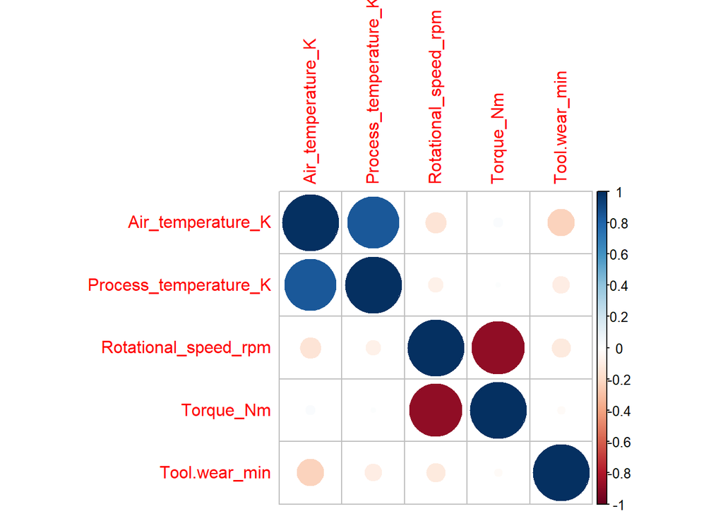

```r
num_vars <- c("Air_temperature_K", "Process_temperature_K", "Rotational_speed_rpm", "Torque_Nm", "Tool.wear_min")
M <- cor(pred_failure[num_vars])
corrplot(M, method="circle")
```

It looks like we have two pairs of variables that are highly correlated with each other, so we will have to remove one of each respectively.:

- Process_temperature_K is correlated with Air_temperature_K
- Rotational_Speed_rpm is negatively correlated with Torque

```r
pred_failure_lim <- pred_failure[c("Type", "Process_temperature_K", "Rotational_speed_rpm", "Tool.wear_min", "Failure_Type")]
str(pred_failure_lim)
```

```
## 'data.frame':    330 obs. of  5 variables:
##  $ Type                 : Factor w/ 3 levels "H","L","M": 2 2 2 2 2 2 3 3 2 2 ...
##  $ Process_temperature_K: num  309 309 309 308 308 ...
##  $ Rotational_speed_rpm : int  2861 1410 1455 1282 1412 1433 2678 1421 1348 1362 ...
##  $ Tool.wear_min        : int  143 191 208 216 218 20 86 119 202 216 ...
##  $ Failure_Type         : Factor w/ 4 levels "Heat Dissipation Failure",..: 3 3 4 2 2 3 3 3 2 2 ...
```

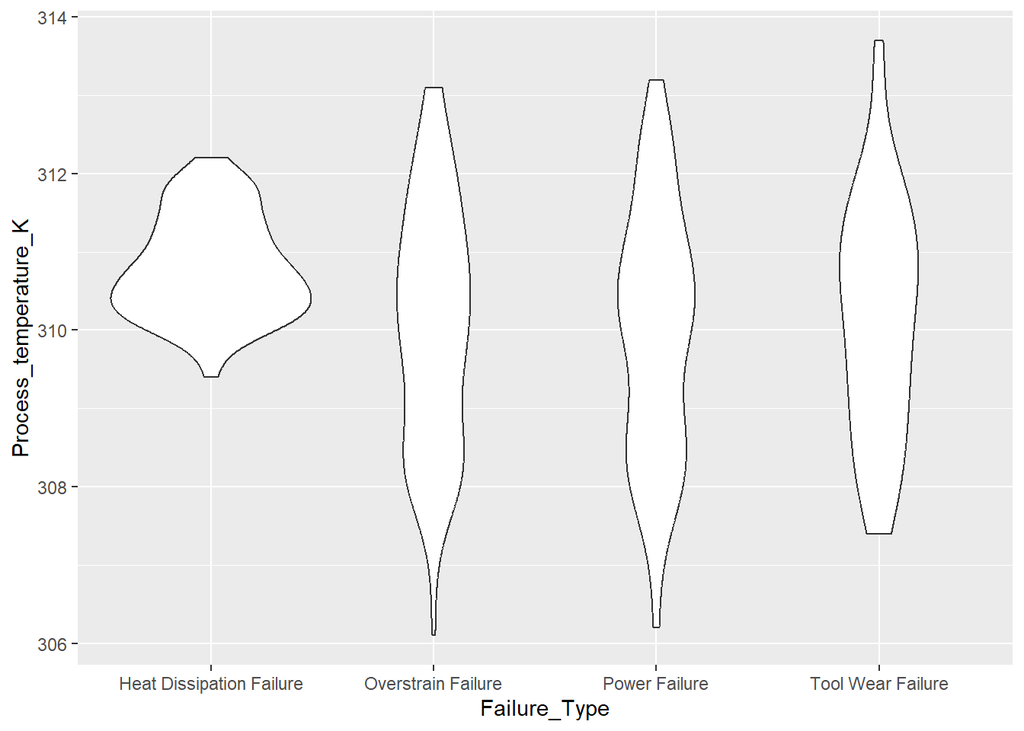

```r
ggplot(pred_failure_lim, aes(x = Failure_Type, y = Process_temperature_K)) +
  geom_violin() + guides(fill = guide_legend(title = "Failure Type vs Air Temperature (K)"))
```

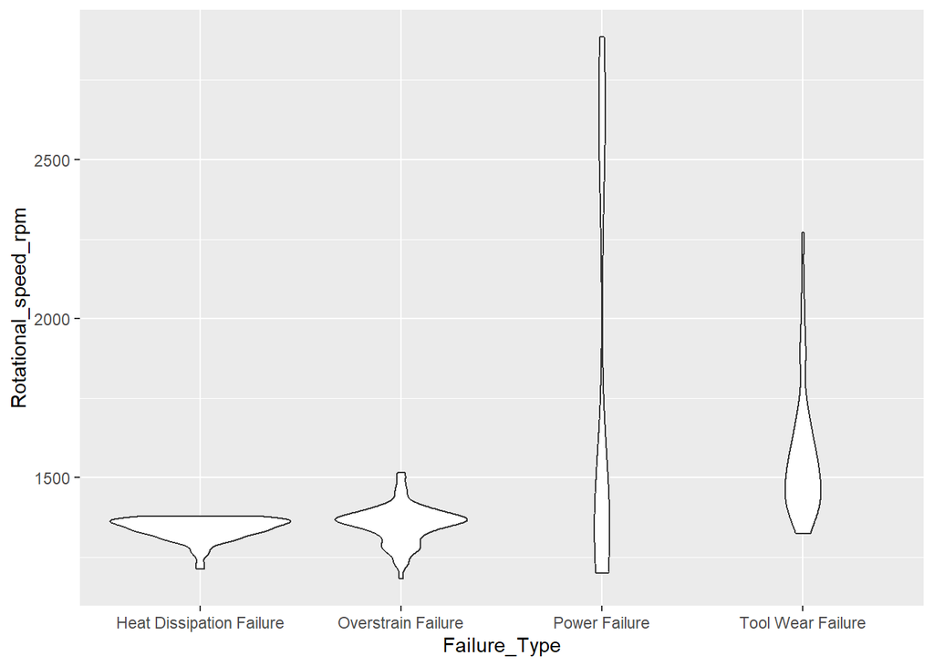

```r
ggplot(pred_failure_lim, aes(x = Failure_Type, y = Rotational_speed_rpm )) +
  geom_violin() + guides(fill = guide_legend(title = "Failure Type vs Rotational_speed_rpm"))
```

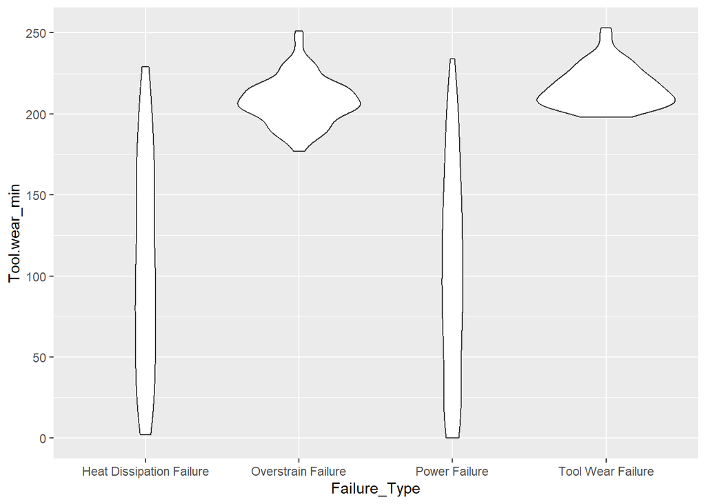

```r
ggplot(pred_failure_lim, aes(x = Failure_Type, y = Tool.wear_min)) +
  geom_violin() + guides(fill = guide_legend(title = "Failure Type vs Tool Wear"))
```

```r
# scaling the process_temperature_K to put it in a more standard range
pred_failure_lim$Process_temperature_K <- scale(pred_failure_lim$Process_temperature_K)
```

## Splitting the data in train and test

```r
set.seed(424242) # setting the seed to always get the same train/test split
#Splitting the data using a function from dplyr package
index <- createDataPartition(pred_failure_lim$Failure_Type, p = .80, list = FALSE)
train <- pred_failure_lim[index,]
test <- pred_failure_lim[-index,]
```

## Train the model

```r
set.seed(424242) # setting the seed to always get the same model_fit
# Training the multinomial model
multinom_model <- multinom(Failure_Type ~ ., data = train)
# Checking the model
summary(multinom_model)
```

```
## Call:
## multinom(formula = Failure_Type ~ ., data = train)
##
## Coefficients:
##                    (Intercept)      TypeL        TypeM Process_temperature_K
## Overstrain Failure   -6.568054  1.9152198 -0.219505671            -0.6814414
## Power Failure       -13.026942 -0.3154991  0.007083278            -0.8299866
## Tool Wear Failure   -28.671594 -0.7922278 -0.603858564            -0.8852425
##                    Rotational_speed_rpm Tool.wear_min
## Overstrain Failure         -0.007929801   0.084584565
## Power Failure               0.009707766  -0.003601596
## Tool Wear Failure           0.008709912   0.085762217
##
## Std. Errors:
##                    (Intercept)     TypeL     TypeM Process_temperature_K
## Overstrain Failure 0.006866321 0.3918198 0.3622721             0.2689465
## Power Failure      0.057772514 0.5862717 0.6080524             0.2296218
## Tool Wear Failure  0.055707378 0.4323671 0.4384585             0.2985927
##                    Rotational_speed_rpm Tool.wear_min
## Overstrain Failure         0.0021038245   0.014040474
## Power Failure              0.0005119106   0.002928435
## Tool Wear Failure          0.0008968452   0.007233242
##
## Residual Deviance: 363.829
## AIC: 399.829
```

### Get model coefficients

```r
exp(coef(multinom_model))
```

```
##                     (Intercept)     TypeL     TypeM Process_temperature_K
## Overstrain Failure 1.404528e-03 6.7884310 0.8029156             0.5058873
## Power Failure      2.200245e-06 0.7294248 1.0071084             0.4360551
## Tool Wear Failure  3.532523e-13 0.4528349 0.5466981             0.4126141
##                    Rotational_speed_rpm Tool.wear_min
## Overstrain Failure            0.9921016     1.0882649
## Power Failure                 1.0097550     0.9964049
## Tool Wear Failure             1.0087480     1.0895472
```

As we expected the main coefficient impacting Overstrain Failure is Tool.wear_min for Type L Power failure and Tool Wear Failure’s main impact is rotational_speed and tool_wear but they are effected differently from the Type.

### Predicting Failure Type on Train Dataset

```r
# Predicting the values for train dataset
train$Failure_Predicted <- predict(multinom_model, newdata = train, "class")
# Building classification table
tab <- table(train$Failure_Type, train$Failure_Predicted)

cm <- confusionMatrix(train$Failure_Predicted, train$Failure_Type)
cm_class <- cm$byClass
cm
```

```
## Confusion Matrix and Statistics
##
##                           Reference
## Prediction                 Heat Dissipation Failure Overstrain Failure
##   Heat Dissipation Failure                       73                  7
##   Overstrain Failure                             10                 53
##   Power Failure                                   5                  0
##   Tool Wear Failure                               2                  3
##                           Reference
## Prediction                 Power Failure Tool Wear Failure
##   Heat Dissipation Failure            27                 1
##   Overstrain Failure                   5                 6
##   Power Failure                       40                 2
##   Tool Wear Failure                    4                27
##
## Overall Statistics
##
##                Accuracy : 0.7283
##                  95% CI : (0.6705, 0.7809)
##     No Information Rate : 0.3396
##     P-Value [Acc > NIR] : < 2.2e-16
##
##                   Kappa : 0.6257
##
##  Mcnemar's Test P-Value : 0.0009209
##
## Statistics by Class:
##
##                      Class: Heat Dissipation Failure Class: Overstrain Failure
## Sensitivity                                   0.8111                    0.8413
## Specificity                                   0.8000                    0.8960
## Pos Pred Value                                0.6759                    0.7162
## Neg Pred Value                                0.8917                    0.9476
## Prevalence                                    0.3396                    0.2377
## Detection Rate                                0.2755                    0.2000
## Detection Prevalence                          0.4075                    0.2792
## Balanced Accuracy                             0.8056                    0.8687
##                      Class: Power Failure Class: Tool Wear Failure
## Sensitivity                        0.5263                   0.7500
## Specificity                        0.9630                   0.9607
## Pos Pred Value                     0.8511                   0.7500
## Neg Pred Value                     0.8349                   0.9607
## Prevalence                         0.2868                   0.1358
## Detection Rate                     0.1509                   0.1019
## Detection Prevalence               0.1774                   0.1358
## Balanced Accuracy                  0.7446                   0.8553
```

```r
recall <- mean(cm_class[,"Sensitivity"])
recall
```

```
## [1] 0.7321742
```

```r
precision <- mean(cm_class[,"Pos Pred Value"])
precision
```

```
## [1] 0.7483015
```

It looks like with the train set that we have 73% accuracy, 73% recall (Sensitivity) and 75% precision (Pos Pred Value)

### Predicting Failure Type on Test Dataset

```r
# Predicting the class for test dataset
test$Failure_Predicted <- predict(multinom_model, newdata = test, "class")
# Building classification table
tab <- table(test$Failure_Type, test$Failure_Predicted)
tab
```

```
##
##                            Heat Dissipation Failure Overstrain Failure
##   Heat Dissipation Failure                       21                  1
##   Overstrain Failure                              0                 14
##   Power Failure                                   6                  3
##   Tool Wear Failure                               1                  2
##
##                            Power Failure Tool Wear Failure
##   Heat Dissipation Failure             0                 0
##   Overstrain Failure                   0                 1
##   Power Failure                       10                 0
##   Tool Wear Failure                    0                 6
```

```r
cm <-confusionMatrix(test$Failure_Predicted, test$Failure_Type)
cm_class <- cm$byClass
cm
```

```
## Confusion Matrix and Statistics
##
##                           Reference
## Prediction                 Heat Dissipation Failure Overstrain Failure
##   Heat Dissipation Failure                       21                  0
##   Overstrain Failure                              1                 14
##   Power Failure                                   0                  0
##   Tool Wear Failure                               0                  1
##                           Reference
## Prediction                 Power Failure Tool Wear Failure
##   Heat Dissipation Failure             6                 1
##   Overstrain Failure                   3                 2
##   Power Failure                       10                 0
##   Tool Wear Failure                    0                 6
##
## Overall Statistics
##
##                Accuracy : 0.7846
##                  95% CI : (0.6651, 0.8769)
##     No Information Rate : 0.3385
##     P-Value [Acc > NIR] : 2.195e-13
##
##                   Kappa : 0.7022
##
##  Mcnemar's Test P-Value : NA
##
## Statistics by Class:
##
##                      Class: Heat Dissipation Failure Class: Overstrain Failure
## Sensitivity                                   0.9545                    0.9333
## Specificity                                   0.8372                    0.8800
## Pos Pred Value                                0.7500                    0.7000
## Neg Pred Value                                0.9730                    0.9778
## Prevalence                                    0.3385                    0.2308
## Detection Rate                                0.3231                    0.2154
## Detection Prevalence                          0.4308                    0.3077
## Balanced Accuracy                             0.8959                    0.9067
##                      Class: Power Failure Class: Tool Wear Failure
## Sensitivity                        0.5263                  0.66667
## Specificity                        1.0000                  0.98214
## Pos Pred Value                     1.0000                  0.85714
## Neg Pred Value                     0.8364                  0.94828
## Prevalence                         0.2923                  0.13846
## Detection Rate                     0.1538                  0.09231
## Detection Prevalence               0.1538                  0.10769
## Balanced Accuracy                  0.7632                  0.82440
```

```r
recall <- mean(cm_class[,"Sensitivity"])
recall
```

```
## [1] 0.7702153
```

```r
precision <- mean(cm_class[,"Pos Pred Value"])
precision
```

```
## [1] 0.8267857
```